# Video Game Sales

*Import dataset and load packages*

Dataset: Video Game Sales by Anand Shaw, Kaggle.com

https://www.kaggle.com/datasets/anandshaw2001/video-game-sales

```r
library(tidyverse)
sales_df <- read_csv(file = "vgsales.csv")
sales_df
```

| Rank | Name | Platform | Year | Genre | Publisher | NA_Sales | EU_Sales | JP_Sales | Other_Sales | Global_Sales |
| --- | --- | --- | --- | --- | --- | --- | --- | --- | --- | --- |
| 1 | Wii Sports | Wii | 2006 | Sports | Nintendo | 41.49 | 29.02 | 3.77 | 8.46 | 82.74 |
| 2 | Super Mario Bros. | NES | 1985 | Platform | Nintendo | 29.08 | 3.58 | 6.81 | 0.77 | 40.24 |
| 3 | Mario Kart Wii | Wii | 2008 | Racing | Nintendo | 15.85 | 12.88 | 3.79 | 3.31 | 35.82 |
| 4 | Wii Sports Resort | Wii | 2009 | Sports | Nintendo | 15.75 | 11.01 | 3.28 | 2.96 | 33.00 |
| 5 | Pokemon Red/Pokemon Blue | GB | 1996 | Role-Playing | Nintendo | 11.27 | 8.89 | 10.22 | 1.00 | 31.37 |
| 6 | Tetris | GB | 1989 | Puzzle | Nintendo | 23.20 | 2.26 | 4.22 | 0.58 | 30.26 |
| 7 | New Super Mario Bros. | DS | 2006 | Platform | Nintendo | 11.38 | 9.23 | 6.50 | 2.90 | 30.01 |
| 8 | Wii Play | Wii | 2006 | Misc | Nintendo | 14.03 | 9.20 | 2.93 | 2.85 | 29.02 |
| 9 | New Super Mario Bros. Wii | Wii | 2009 | Platform | Nintendo | 14.59 | 7.06 | 4.70 | 2.26 | 28.62 |
| 10 | Duck Hunt | NES | 1984 | Shooter | Nintendo | 26.93 | 0.63 | 0.28 | 0.47 | 28.31 |

[output cut: 9990 more lines]

# 1 Exploratory Data Analysis

## 1.1 Data Description

**This dataset describes video game sales across platforms, genres, and regions.**

## 1.2 Key Concepts in Statistics

Assume data is population for only this section. You might need to change this section depending on what you plan to research in Section 2.

1. What is the population? Check Section 2 for this.

**All video game sales across platforms, genres, and regions.**

2. What is the sample? Check Section 2 for this.

**Video game sales from more than 16,500 games**

3. What are the variables? What type of variables are they?
- **Platform: Categorical**
- **Genre: Categorical**
- **North American Sales: Quantitative**
- **Japan Sales: Quantitative**
- **Global Sales: Quantitative**
- **Year: Categorical**
4. What are the parameters?
- Mean sales of all video games
- Proportion of all games released for specific platforms
- Proportion of all games released in each year
- Proportion of all video game sales from each country
- Proportion of all video games belonging to specific genres
5. What are the statistics?
- Mean sales of 16598 video games
- Proportion of 16598 games released for specific platforms
- Proportion of 16598 games released in each year
- Proportion of 16598 video game sales from each country
- Proportion of 16598 video games belonging to specific genres

## 1.3 Key Concepts in Statistics

1. Find the distribution of the two quantitative variables: center, spread and shape.

### Variable one: North American Video Game Sales (in millions)

```r
naSales <- sales_df %>% pull(NA_Sales)

#Center
naSales %>% mean()
```

```
## [1] 0.2646674
```

```r
#Spread
naSales %>% sd()
```

```
## [1] 0.816683
```

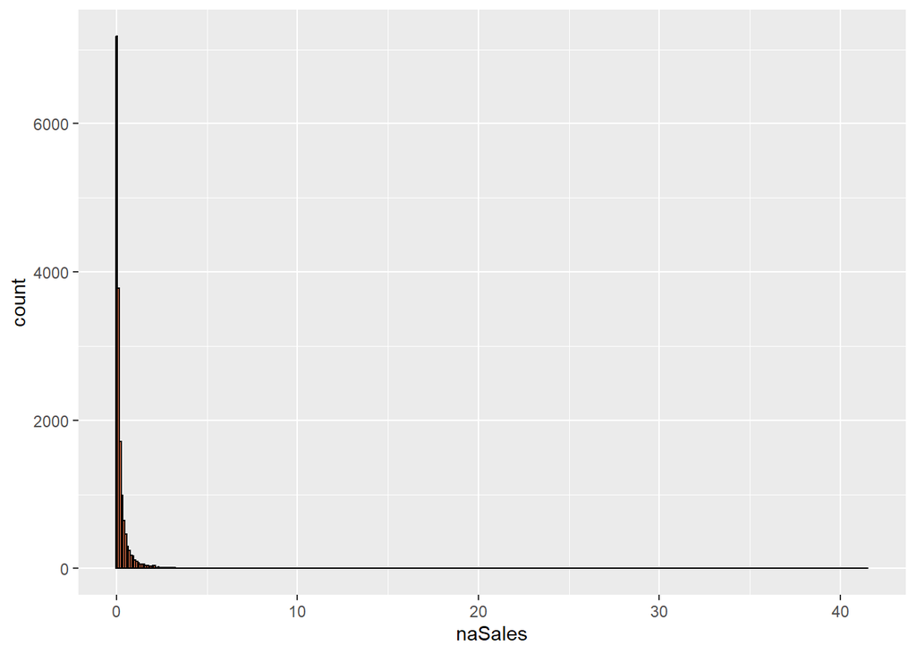

```r
#Shape
ggplot(mapping = aes(x = naSales)) +
  geom_histogram(color = "black", fill = "coral", binwidth = 0.1)
```

### Variable two: Japan Video Game Sales (in millions)

```r
jpSales <- sales_df %>% pull(JP_Sales)

#Center
jpSales %>% mean()
```

```
## [1] 0.07778166
```

```r
#Spread
jpSales %>% sd()
```

```
## [1] 0.3092906
```

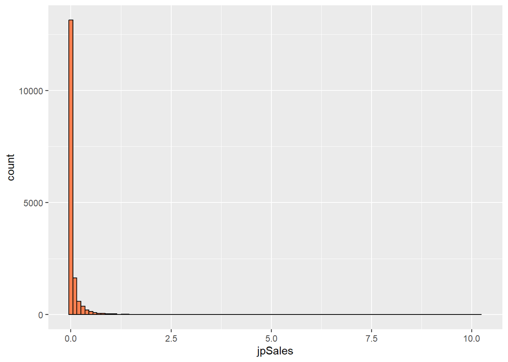

```r
#Shape
ggplot(mapping = aes(x = jpSales)) +
  geom_histogram(color = "black", fill = "coral", binwidth = 0.1)
```

**Distribution is skewed right for both**

2. Create bar graph and relative frequency table for the two categorical variables.

### Variable one

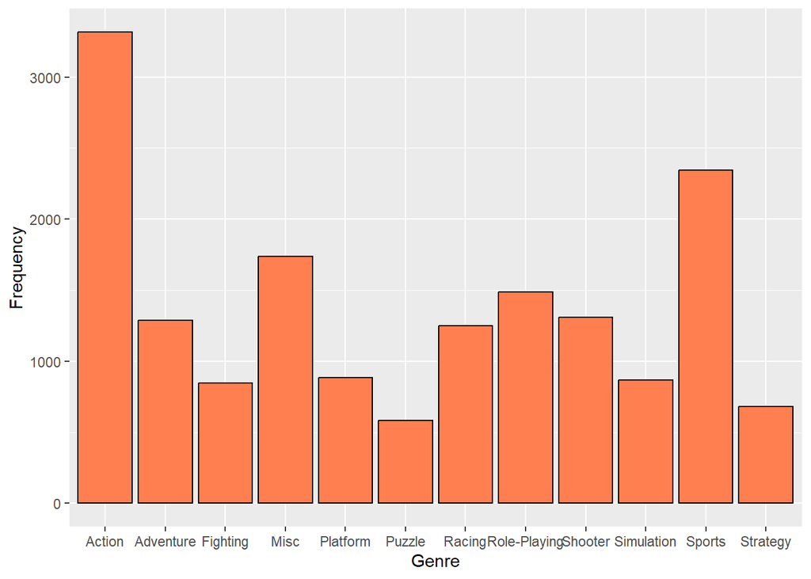

```r
#Frequency Bar graph
sales_df %>%
  ggplot(mapping = aes(x = Genre)) +
  geom_bar(color = "black", fill = "coral") +
  labs(y = "Frequency")
```

```r
#Rel Frequency
sales_df%>%
  count(Genre, name = "Frequency")%>%
  mutate(rel_freq = Frequency/sum(Frequency))
```

| Genre | Frequency | rel_freq |
| --- | --- | --- |
| Action | 3316 | 0.19978311 |
| Adventure | 1286 | 0.07747921 |
| Fighting | 848 | 0.05109049 |
| Misc | 1739 | 0.10477166 |
| Platform | 886 | 0.05337993 |
| Puzzle | 582 | 0.03506447 |
| Racing | 1249 | 0.07525003 |
| Role-Playing | 1488 | 0.08964936 |
| Shooter | 1310 | 0.07892517 |
| Simulation | 867 | 0.05223521 |

[output cut: 2 more lines]

### Variable two

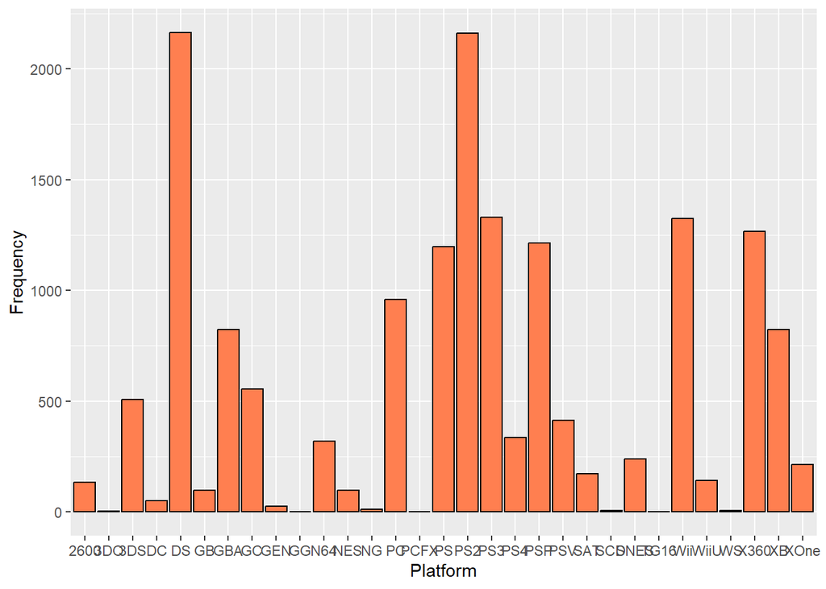

```r
#Frequency Bar graph
sales_df %>%
  ggplot(mapping = aes(x = Platform)) +
  geom_bar(color = "black", fill = "coral") +
  labs(y = "Frequency")
```

```r
#Rel Frequency
sales_df%>%
  count(Platform, name = "Frequency")%>%
  mutate(rel_freq = Frequency/sum(Frequency))
```

| Platform | Frequency | rel_freq |
| --- | --- | --- |
| 2600 | 133 | 8.013014e-03 |
| 3DO | 3 | 1.807447e-04 |
| 3DS | 509 | 3.066635e-02 |
| DC | 52 | 3.132908e-03 |
| DS | 2163 | 1.303169e-01 |
| GB | 98 | 5.904326e-03 |
| GBA | 822 | 4.952404e-02 |
| GC | 556 | 3.349801e-02 |
| GEN | 27 | 1.626702e-03 |
| GG | 1 | 6.024822e-05 |

[output cut: 21 more lines]

# 2 Probability Distributions

Assume the data uploaded is population data in this subsection only.

## 2.1 Qualitative Data

Select one qualitative variable and use one level of the qualitative variable as success.

**Selected Variable: Genre** **Success: Genre = Puzzle**

1. Show the number of successes is from binomial distribution. P(X)
- There is a fixed number of observations (n = 16598)
- Each trial is independent
- Only two outcomes (Genre = “Puzzle” or Genre $\ne$ “Puzzle”)

```r
n <- 16598
x <- sales_df %>% filter(Genre == "Puzzle") %>% pull(Genre) %>% length

p <- x/n
p
```

```
## [1] 0.03506447
```

2. Find the probability the random variable is more than its mean. P(X > 582)

```r
1 - pbinom(q = 581, size = n, prob = p)
```

```
## [1] 0.5058083
```

3. Find the sampling distribution of the sample proportion of the qualitative variable with a sample size of at least 50 (this number might need to change to satisfy the requirement).

*Mean*

```r
p
```

```
## [1] 0.03506447
```

*Standard Deviation*

```r
sqrt(p * (1- p)/n)
```

```
## [1] 0.001427759
```

*Shape*

Shape = **approx. normal**

```r
n*p*(1 - p) >= 10
```

```
## [1] TRUE
```

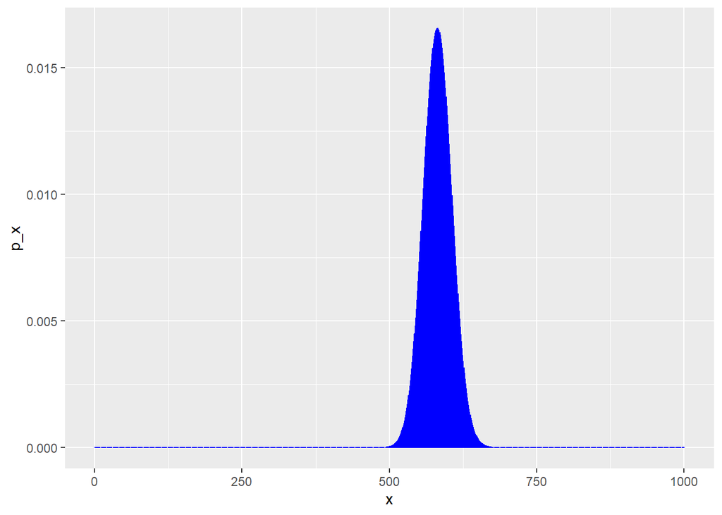

```r
puzzles_pmf <- tibble(x = 0:1000, #Applying cutoff at x = 1000 for better visualization, the odds beyond 1000 or essentially 0
                      p_x = dpois(x = 0:1000, lambda = 582))
puzzles_pmf %>%
  ggplot(mapping = aes(x = x, y = p_x)) +
  geom_col(color = "blue")
```

```r
puzzles_pmf
```

| x | p_x |
| --- | --- |
| 0 | 1.740250e-253 |
| 1 | 1.012825e-250 |
| 2 | 2.947321e-248 |
| 3 | 5.717804e-246 |
| 4 | 8.319404e-244 |
| 5 | 9.683787e-242 |
| 6 | 9.393273e-240 |
| 7 | 7.809836e-238 |
| 8 | 5.681655e-236 |
| 9 | 3.674137e-234 |

[output cut: 991 more lines]

## 2.2 Quantitative Data

Select one quantitative variable.

**Selected Variable: Japan Sales**

1. Check if the quantitative variable is from normal distribution.

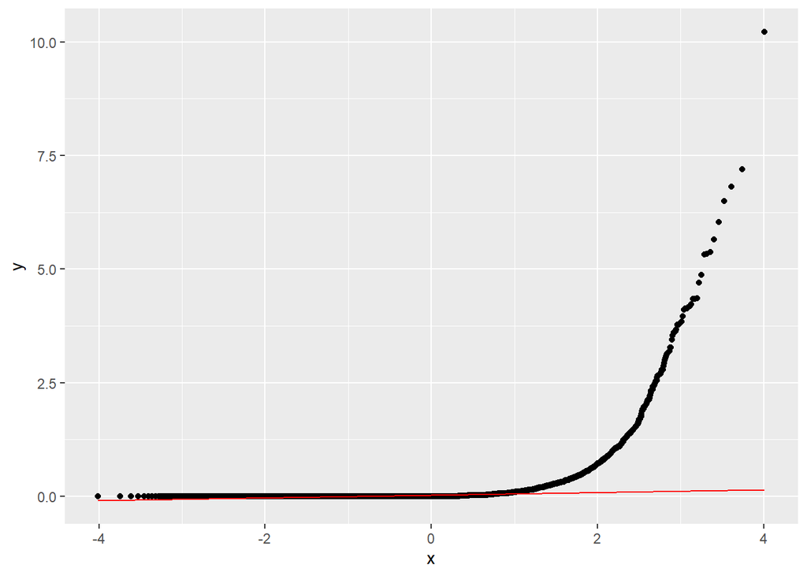

```r
sales_df %>%
  ggplot(mapping = aes(sample = JP_Sales)) +
  stat_qq() +
  stat_qq_line(color = "red")
```

2. Find the sampling distribution of the sample mean of the quantitative variable with sample size of the sample size of at least 50.

*Mean*

```r
sales <- sales_df %>% pull(JP_Sales)

mean(sales)
```

```
## [1] 0.07778166
```

*Standard Deviation*

```r
sd(sales)/sqrt(0.07778166)
```

```
## [1] 1.108991
```

*Shape = Approximately Normal* n >= 30

3. Find a probability of sample mean is greater than a number you choose. P(X > 1)

```r
1 - pnorm(q = 1,
      mean = 0.07778166,
      sd = 1.108991)
```

```
## [1] 0.2028221
```

# 3 One Sample: Confidence Interval and Hypothesis Testing

Assume full data is a sample for this section.

## Section 3.1 Confidence interval

1. Find the point estimate and 98% confidence interval for the population proportion from the variable selected in Section 2.1 part a).

*Point Estimate*

```r
#Point Estimate
p_hat <- p
p_hat
```

```
## [1] 0.03506447
```

*Check Requirements* 1) n <= 0.05 N 2) Simple random sample (assume yes) 3) n p_hat (1-p_hat) >= 10

```r
n* p_hat* ((1-p_hat)) >= 10
```

```
## [1] TRUE
```

*Construct and Interpret Confidence Interval*

```r
prop.test(x = 582, n = 16598, conf.level = 0.98)
```

```
##
##  1-sample proportions test with continuity correction
##
## data:  582 out of 16598, null probability 0.5
## X-squared = 14350, df = 1, p-value < 2.2e-16
## alternative hypothesis: true p is not equal to 0.5
## 98 percent confidence interval:
##  0.03186289 0.03857188
## sample estimates:
##          p
## 0.03506447
```

*We are 98% confident that proportion of video games with the genre of “Puzzle” is between 0.03186289 and 0.03857188*

2. Find the point estimate and 99% confidence interval for the population mean from the variable selected in Section 2.1 part b).

*Point Estimate*

```r
mean(sales)
```

```
## [1] 0.07778166
```

*Check Requirements* 1) n <= 0.05 N 2) Simple random sample 3) n >= 30 or X ~ Normal

```r
n >= 30
```

```
## [1] TRUE
```

*Construct and Interpret Confidence Interval*

```r
t.test(x = sales_df %>% pull(JP_Sales), conf.level = 0.99)
```

```
##
##  One Sample t-test
##
## data:  sales_df %>% pull(JP_Sales)
## t = 32.399, df = 16597, p-value < 2.2e-16
## alternative hypothesis: true mean is not equal to 0
## 99 percent confidence interval:
##  0.07159714 0.08396618
## sample estimates:
##  mean of x
## 0.07778166
```

## Section 3.2 One sample proportion hypothesis testing

Formulate a research question to conduct a one-sample proportion hypothesis test based on the variable from section 2.1.

1. State your research question. *Testing if the proportion of video games in the genre “Puzzle” is greater than 4% this year at alpha level = 0.01?*
2. Conduction hypothesis test.

**Step 1**: State the hypotheses

$H_0: p = .04$

$H_A: p > .04$

**Step 2**: What is the level of significance, $\alpha$?

$= 0.01 $

**Step 0**: Check requirement

- n $\le$ 0.05N (independent samples)
- Simple random sample
- $np_0(1-p_0) $

```r
n* p* ((1-p)) >= 10
```

```
## [1] TRUE
```

**Step 3**: Calculate test statistics and p-value.

```r
n <- sales_df %>% pull(Genre) %>% length()
x <- sales_df %>% filter(Genre == "Puzzle") %>% pull(Genre) %>% length
n
```

```
## [1] 16598
```

```r
z_0 <- (x/n - 0.04)/ (sqrt(0.04 * (1-0.04)/n))
z_0
```

```
## [1] -3.244864
```

```r
prop.test(x = 582, n = 16598, p = 0.04, alternative = "greater", correct = F)
```

```
##
##  1-sample proportions test without continuity correction
##
## data:  582 out of 16598, null probability 0.04
## X-squared = 10.529, df = 1, p-value = 0.9994
## alternative hypothesis: true p is greater than 0.04
## 95 percent confidence interval:
##  0.03279075 1.00000000
## sample estimates:
##          p
## 0.03506447
```

**Step 4**: Decision *Since p-value = 0.9994 and is greater than alpha level 0.01, we fail to reject H_0*

**Step 5**: Conclusion *There is insufficient evidence at alpha level = 0.01 that the proportion of video games with the genre “Puzzle” is greater than 4%.*

## Section 3.2 One sample mean (t test) hypothesis testing

Formulate a research question to conduct a one sample t test hypothesis test based on the variable in section 2.2.

**Step 1**: State the hypotheses

$H_0: = 80,000 $

$H_A: > 80,000 $

**Step 2**: What is the level of significance, $\alpha$?

$= 0.05 $

**Step 0**: Check requirement

- n $\le$ 0.05N (independent samples)
- Simple random sample
- n $\ge$ 30 or X ～ Normal

**Step 3**: Calculate test statistics and p-value.

```r
sales <- sales_df %>% pull(JP_Sales)
t.test(sales, mu = .08, alternative = "greater")
```

```
##
##  One Sample t-test
##
## data:  sales
## t = -0.92404, df = 16597, p-value = 0.8223
## alternative hypothesis: true mean is greater than 0.08
## 95 percent confidence interval:
##  0.07383263        Inf
## sample estimates:
##  mean of x
## 0.07778166
```

**Step 4**: Decision Since p-value = 0.8223 > 0.05, we fail to reject H_0: $= 80,000 $

# 4 Two Samples t-test : Independent Sampling Method.

Create a research question to perform a two-sample mean (independent t-test) hypothesis test using the variables you chose in section 2.

1. Create the research question.

**Is the mean value of video game sales greater in North America than in Japan at a 0.05 significance level?**

b)Run a hypothesis test to test your hypothesis.

**Step 1**: State the hypotheses

$H_0: \mu_1 = \mu_2$

$H_A: \mu_1 > \mu_2$

**Step 2**: What is the level of significance, $\alpha$?

$\alpha = 0.05$

**Step 0**: Check requirement

- n1 <= 0.05N1 and n2 <= 0.05N2
- Simple Random Samples
- n1 >= 30, n2 >= 30

```r
n1 <- sales_df %>% pull(NA_Sales) %>% length()
n2 <- sales_df %>% pull(JP_Sales) %>% length()
n1 >= 30
```

```
## [1] TRUE
```

```r
n2 >= 30
```

```
## [1] TRUE
```

**Step 3**: Calculate test statistics and p-value.

```r
t.test(x = sales_df %>% pull(NA_Sales), y = sales_df %>% pull(JP_Sales), mu = 0, alternative = "greater", var.equal = F)
```

```
##
##  Welch Two Sample t-test
##
## data:  sales_df %>% pull(NA_Sales) and sales_df %>% pull(JP_Sales)
## t = 27.571, df = 21262, p-value < 2.2e-16
## alternative hypothesis: true difference in means is greater than 0
## 95 percent confidence interval:
##  0.1757357       Inf
## sample estimates:
##  mean of x  mean of y
## 0.26466743 0.07778166
```

**Step 4**: Decision

Since p-value = 2.2e-16 < 0.05, reject $H_0$

**Step 5**: Conclusion

There is sufficient evidence at $\alpha = 0.05$ to conclude that the average video game sales in NA is higher than in JP

2. Use the Confidence interval to test your hypothesis. **Step 1**: State the hypotheses

$H_0: \mu_d = 0$

**Step 2**: Construct Confidence Interval

```r
t.test(x = sales_df %>% pull(NA_Sales), y = sales_df %>% pull(JP_Sales), conf.level = 0.90)
```

```
##
##  Welch Two Sample t-test
##
## data:  sales_df %>% pull(NA_Sales) and sales_df %>% pull(JP_Sales)
## t = 27.571, df = 21262, p-value < 2.2e-16
## alternative hypothesis: true difference in means is not equal to 0
## 90 percent confidence interval:
##  0.1757357 0.1980358
## sample estimates:
##  mean of x  mean of y
## 0.26466743 0.07778166
```

**Step 3**: Decision

Since p-value = 2.2e-16 < 0.05, reject $H_0$

**Step 4**: Conclusion

There is sufficient evidence at $\alpha = 0.05$ to conclude that the average video game sales in NA is higher than in JP

# 5 Simple Linear regression

Use two quantitative variables to show if there is a linear relationship between them. *Is there a linear relationship between video game sales in North America and sales in Japan?*

**Step 1**: State the hypotheses

$H_0: \beta = 0$

$H_A: \beta \neq 0$

**Step 2**: What is the level of significance, $\alpha$?

$= 0.01 $

**Step 0**: Check requirement

- *SRS*
- Resid ~Normal

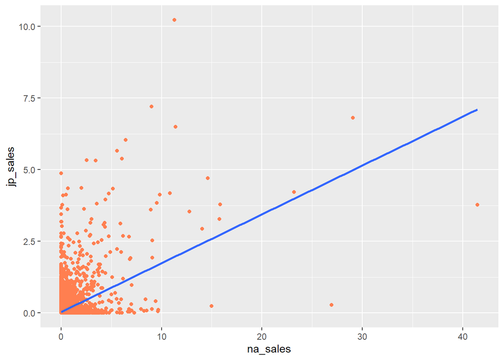

```r
na_sales <- sales_df %>% pull(NA_Sales)
jp_sales <- sales_df %>% pull(JP_Sales)
#Draws line
sales_df %>%
  ggplot(mapping = aes(x = na_sales, y = jp_sales)) +
  geom_point(color = "coral") +
  geom_smooth(method = "lm", se = F)
```

**Step 3**: Calculate test statistics and p-value.

```r
sales_mod <- lm(formula = jp_sales ~ na_sales, data = sales_df)
sales_mod %>% summary()
```

```
##
## Call:
## lm(formula = jp_sales ~ na_sales, data = sales_df)
##
## Residuals:
##     Min      1Q  Median      3Q     Max
## -4.3400 -0.0634 -0.0412 -0.0127  8.2676
##
## Coefficients:
##             Estimate Std. Error t value Pr(>|t|)
## (Intercept) 0.032698   0.002254   14.51   <2e-16 ***
## na_sales    0.170342   0.002626   64.88   <2e-16 ***
## ---
## Signif. codes:  0 '***' 0.001 '**' 0.01 '*' 0.05 '.' 0.1 ' ' 1
##
## Residual standard error: 0.2762 on 16596 degrees of freedom
## Multiple R-squared:  0.2023, Adjusted R-squared:  0.2023
## F-statistic:  4209 on 1 and 16596 DF,  p-value: < 2.2e-16
```

*p-value = 0*

**Step 4**: Decision Since p-value = 0, which is less than alpha = 0.01, we reject H_0

**Step 5**: Conclusion There is sufficient evidence at alpha = 0.01 that there is a linear relationship between video game sales in North America and Japan.

# 6: Report

One sample proportion hypothesis testing: Hypothesis: *Testing if the proportion of video games in the genre “Puzzle” is greater than 4% this year at alpha level = 0.01?* Conclusion: With our one sample proportion hypothesis testing. At alpha = 0.01, there is insufficient evidence that the proportion of video games with the genre “Puzzle” is greater than 4%, which is also validated by our 98% proportion confidence interval.

Section 4: Independent Sampling Method: Hypothesis: **Is the mean value of video game sales greater in North America than in Japan at a 0.05 significance level?** Conclusion: There is sufficient evidence at $\alpha = 0.05$ to conclude that the average video game sales in NA is higher than in JP

Confidence interval to test hypothesis (conclusion): There is sufficient evidence at $\alpha = 0.05$ to conclude that the average video game sales in NA is higher than in JP

Section 5: Simple Linear Regression: Hypothesis: *Is there a linear relationship between video game sales in North America and sales in Japan?* Conclusion: There is sufficient evidence at $\alpha = 0.01$ that there is a linear relationship between video game sales in North America and Japan.